# Scraping: Challenge 2

Pablo Barbera

January 22, 2016

The purpose of this challenge is to analyze the social media posts of the current Republican and Democratic candidates for president. To facilitate the data collection, focus on only two of them. If there’s time at the end of this challenge, you can add a few more.

Let’s start with Twitter: download their most recent 1,000 tweets.

```r
library(smappR)
getTimeline(screen_name="HillaryClinton", filename="clinton.json", n=1000,
            oauth_folder="~/git/data-science-workshop/scraping/credentials")
```

```
## 200 tweets. Max id: 686706267679633408
## 168 hits left
## 400 tweets. Max id: 678605426556973056
## 167 hits left
## 600 tweets. Max id: 674060790492737536
## 166 hits left
## 800 tweets. Max id: 667366525427449856
## 165 hits left
## 1000 tweets. Max id: 664174649773715456
```

```r
getTimeline(screen_name="berniesanders", filename="sanders.json", n=1000,
            oauth_folder="~/git/data-science-workshop/scraping/credentials")
```

```
## 200 tweets. Max id: 686743363081515009
## 163 hits left
## 400 tweets. Max id: 684447157018046464
## 162 hits left
## 600 tweets. Max id: 681141639507775488
## 161 hits left
## 800 tweets. Max id: 677509585129705472
## 160 hits left
## 1000 tweets. Max id: 674028395152343040
```

```r
library(stringr)
library(streamR)
clinton <- parseTweets("clinton.json")
```

```
## 1000 tweets have been parsed.
```

```r
sanders <- parseTweets("sanders.json")
```

```
## 1000 tweets have been parsed.
```

```r
popularHashtags <- function(text){
  ht <- str_extract_all(text, "#(\\d|\\w)+")
  ht <- unlist(ht)
  head(sort(table(ht), decreasing = TRUE))
}

popularHashtags(clinton$text)
```

```
## ht
##   #DemDebate   #GOPdebate   #ImWithHer   #GOPDebate #Hillary2016
##          108           60           31           22           17
##        #SOTU
##           15
```

```r
popularHashtags(sanders$text)
```

```
## ht
##        #DemDebate      #FeelTheBern        #BreakEmUp #DebateWithBernie
##                43                32                30                28
##         #iacaucus        #GOPDebate
##                18                16
```

Prepare a comparison cloud showing what words are they using with different frequency. Note that in this case we probably don’t want to get rid of punctuation. What do you learn?

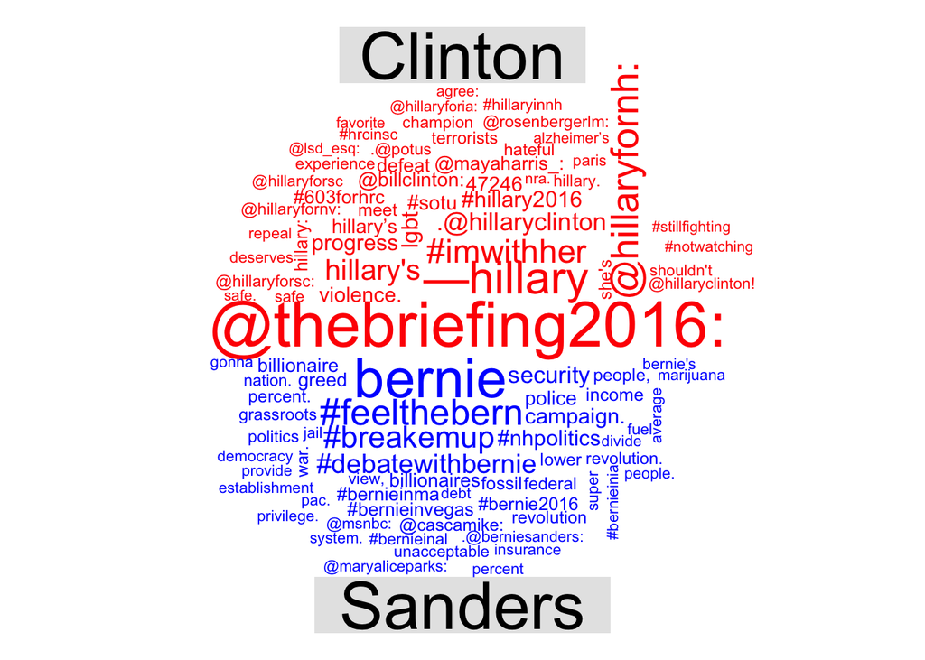

```r
# Create large documents with posts
clinton <- paste(clinton$text, collapse = " ")
sanders    <- paste(sanders$text, collapse = " ")
# Create DTM and preprocess
library(tm)
candidates <- VCorpus(VectorSource(c("Clinton" = clinton, "Sanders" = sanders)))
candidates <- tm_map(candidates, content_transformer(tolower))
candidates <- tm_map(candidates, stripWhitespace)
dtm <- DocumentTermMatrix(candidates)
## Label the two groups
dtm$dimnames$Docs = c("Clinton", "Sanders")
## Transpose matrix so that we can use it with comparison.cloud
tdm <- t(dtm)
## Compute TF-IDF transformation
tdm <- as.matrix(weightTfIdf(tdm))

## Display the two word clouds
library(wordcloud)
comparison.cloud(tdm, max.words=100, colors=c("red", "blue"))
```

```r
fb_oauth <- 'XXXXXXXX'
```

```r
library(Rfacebook)
clinton <- getPage("HillaryClinton", token=fb_oauth, n=500)
```

```
## 100 posts 200 posts 300 posts 400 posts 500 posts
```

```r
sanders <- getPage("berniesanders", token=fb_oauth, n=500)
```

```
## 100 posts 200 posts 300 posts 400 posts 500 posts
```

This time, let’s focus on their relative popularity. How many likes, comments, and shares do each of these candidates receive on their posts, on average? Who is more popular?

```r
summary(clinton[,c("likes_count", "comments_count", "shares_count")])
```

```
##   likes_count     comments_count     shares_count
##  Min.   :    24   Min.   :   15.0   Min.   :    0
##  1st Qu.:   555   1st Qu.:  346.8   1st Qu.:    7
##  Median :  6206   Median :  694.5   Median :  495
##  Mean   : 10667   Mean   :  906.3   Mean   : 1193
##  3rd Qu.: 11414   3rd Qu.: 1134.5   3rd Qu.: 1190
##  Max.   :327284   Max.   :13610.0   Max.   :40340
```

```r
summary(sanders[,c("likes_count", "comments_count", "shares_count")])
```

```
##   likes_count     comments_count     shares_count
##  Min.   :   370   Min.   :   38.0   Min.   :    0
##  1st Qu.:  9139   1st Qu.:  327.0   1st Qu.: 1153
##  Median : 16312   Median :  486.5   Median : 3140
##  Mean   : 21462   Mean   :  699.5   Mean   : 5340
##  3rd Qu.: 26735   3rd Qu.:  724.5   3rd Qu.: 5988
##  Max.   :295025   Max.   :20376.0   Max.   :95084
```

Finally, examine whether there is any trend on their popularity over time by creating a figure that displays the average number of likes receive on their post by month.

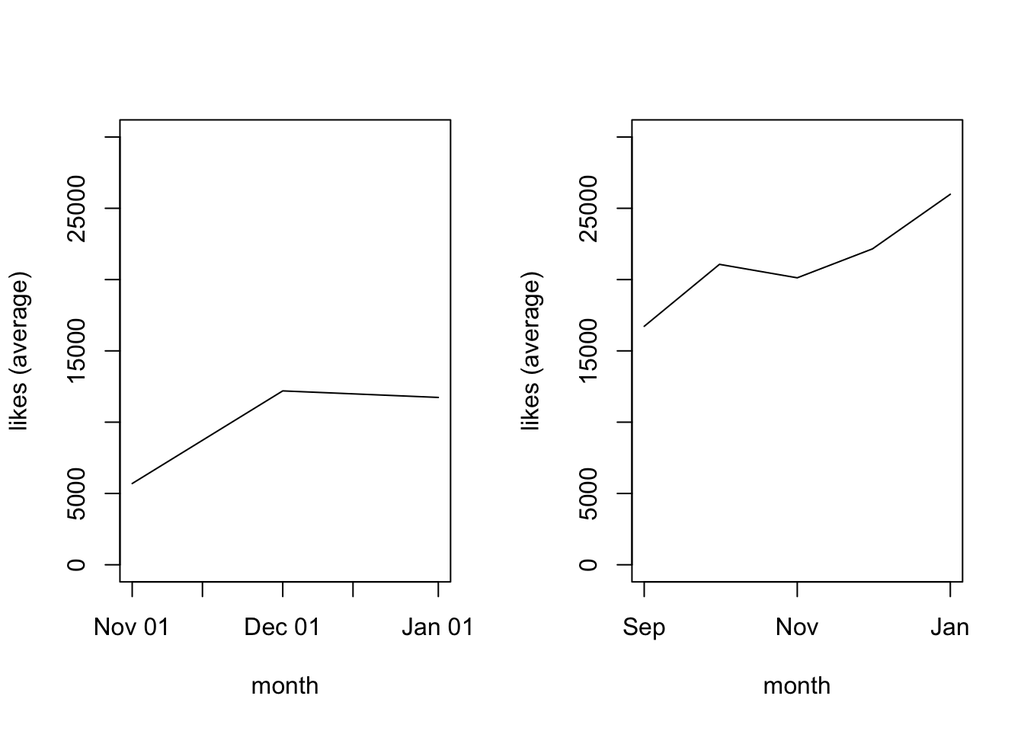

```r
clinton$month <- as.Date(paste0(substr(clinton$created_time, 1, 7), '-01'))
sanders$month <- as.Date(paste0(substr(sanders$created_time, 1, 7), '-01'))
agg.clinton <- aggregate(clinton$likes_count, by=list(month=clinton$month), FUN=mean)
agg.sanders <- aggregate(sanders$likes_count, by=list(month=sanders$month), FUN=mean)
par(mfrow=c(1,2))
plot(agg.clinton$month, agg.clinton$x, type="l", ylim=c(0, 30000), xlab="month", ylab="likes (average)")
plot(agg.sanders$month, agg.sanders$x, type="l", ylim=c(0, 30000), xlab="month", ylab="likes (average)")
```